# Intelligent Systems - NLP Deliverable

Racil Kacem

January 12, 2021

The goal of this document is to analyze the book *Harry Potter and the Order of the Phoenix* which was published on June 21, 2003.

Indeed, it is the Harry Potter book with the highest number of words. We will try to look to the words which are used (total number of words, total number of unique words, characters, word frequency etc.) and find patterns in the text.

Thanks to this analysis, we will see that is possible to know who are the most important characters of the book and answer some interesting questions such as:

- Who is Harry’s closest friend ?
- Is this book a negative or positive book ?

Link to the GitHub repository : https://github.com/racilk/Harry-Potter-NLP

## Preparation

### Check working directory

In this project, we don’t have to check the working directory. Indeed, the corpus is hosted online and we’ll only need to import it using its link.

### Load libraries

```r
library(reshape2)
library(NLP)
library(stringr)
library(tm)
library(SnowballC)
library(wordcloud)
library(RColorBrewer)
library(syuzhet)
library(ggplot2)
library(rJava)
.jinit(parameters="-Xmx4g")
```

```
[1] 0
```

```r
library(openNLP)
library(openNLPmodels.en)
```

## Load corpus

The text file is hosted online on my GithHub repository.

```r
file = "https://github.com/racilk/Harry-Potter-NLP/blob/main/hp.txt?raw=true"
text = readLines(file)
# Load the data as a corpus
corpus = Corpus(VectorSource(text))
```

We can check the length of the corpus:

```r
length(corpus)
```

```
[1] 9296
```

## Create a default term document matrix

```r
tdm = TermDocumentMatrix(corpus)
```

```r
tdm
```

```
<<TermDocumentMatrix (terms: 24207, documents: 9296)>>
Non-/sparse entries: 193250/224835022
Sparsity           : 100%
Maximal term length: 95
Weighting          : term frequency (tf)
```

```r
length(dimnames(tdm)$Terms)
```

```
[1] 24207
```

```r
freq=rowSums(as.matrix(tdm))
head(freq,10)
```

```
     and    harry    order  phoenix   potter      the  rowling  chapter      one demented
    5905     2640       65       21       62    11696        1       43      412        1
```

If we plot those frequencies ordered, we can see how the corpus behaves following Zipf’s law.

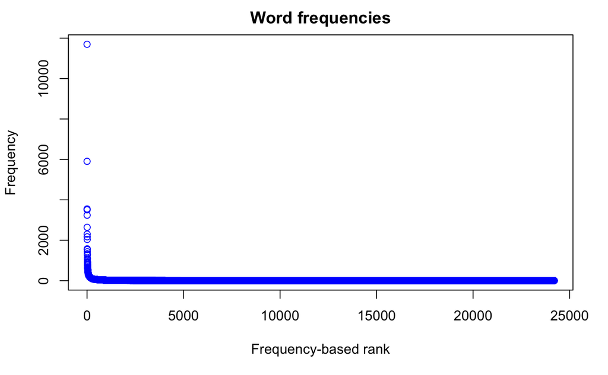

```r
plot(sort(freq, decreasing = T),col="blue",main="Word frequencies", xlab="Frequency-based rank", ylab = "Frequency")
```

We can now print the ten most frequent terms. Given that we haven’t done any transformation on the text file yet, it will mostly be stopwords.

```r
tail(sort(freq),n=10)
```

```
 with  that   you   had harry   his  said   was   and   the
 1575  2038  2170  2304  2640  3239  3504  3549  5905 11696
```

An other measure of the vocabulary richness of the book will be the number of words which appear once:

```r
sum(freq == 1)
```

```
[1] 12600
```

We can check that 12600 terms out of 24207 only appear once in our corpus.

## Create a TDM after applying transformations to the corpus

We will now apply transformations to the text in order to delete the stopwords, the numbers, the punctuation etc. First, we can print the different transformations and the stopwords.

```r
getTransformations()
```

```
[1] "removeNumbers"     "removePunctuation" "removeWords"       "stemDocument"      "stripWhitespace"
```

```r
stopwords()
```

```
  [1] "i"          "me"         "my"         "myself"     "we"         "our"        "ours"       "ourselves"
  [9] "you"        "your"       "yours"      "yourself"   "yourselves" "he"         "him"        "his"
 [17] "himself"    "she"        "her"        "hers"       "herself"    "it"         "its"        "itself"
 [25] "they"       "them"       "their"      "theirs"     "themselves" "what"       "which"      "who"
 [33] "whom"       "this"       "that"       "these"      "those"      "am"         "is"         "are"
 [41] "was"        "were"       "be"         "been"       "being"      "have"       "has"        "had"
 [49] "having"     "do"         "does"       "did"        "doing"      "would"      "should"     "could"
 [57] "ought"      "i'm"        "you're"     "he's"       "she's"      "it's"       "we're"      "they're"
 [65] "i've"       "you've"     "we've"      "they've"    "i'd"        "you'd"      "he'd"       "she'd"
 [73] "we'd"       "they'd"     "i'll"       "you'll"     "he'll"      "she'll"     "we'll"      "they'll"
 [81] "isn't"      "aren't"     "wasn't"     "weren't"    "hasn't"     "haven't"    "hadn't"     "doesn't"
 [89] "don't"      "didn't"     "won't"      "wouldn't"   "shan't"     "shouldn't"  "can't"      "cannot"
 [97] "couldn't"   "mustn't"    "let's"      "that's"     "who's"      "what's"     "here's"     "there's"
[105] "when's"     "where's"    "why's"      "how's"      "a"          "an"         "the"        "and"
[113] "but"        "if"         "or"         "because"    "as"         "until"      "while"      "of"
[121] "at"         "by"         "for"        "with"       "about"      "against"    "between"    "into"
[129] "through"    "during"     "before"     "after"      "above"      "below"      "to"         "from"
[137] "up"         "down"       "in"         "out"        "on"         "off"        "over"       "under"
[145] "again"      "further"    "then"       "once"       "here"       "there"      "when"       "where"
[153] "why"        "how"        "all"        "any"        "both"       "each"       "few"        "more"
[161] "most"       "other"      "some"       "such"       "no"         "nor"        "not"        "only"
[169] "own"        "same"       "so"         "than"       "too"        "very"
```

Let’s apply the different transformations:

```r
corpus = tm_map(corpus, content_transformer(tolower))
```

```
transformation drops documents
```

```r
corpus = tm_map(corpus,removeWords,stopwords())
```

```
transformation drops documents
```

```r
corpus = tm_map(corpus,removePunctuation)
```

```
transformation drops documents
```

```r
corpus = tm_map(corpus,removeNumbers)
```

```
transformation drops documents
```

```r
corpus = tm_map(corpus,stripWhitespace)
```

```
transformation drops documents
```

Let’s inspect the beginning of the book to be sure that the transformations have correctly been applied.

```r
inspect(corpus[1:50])
```

```
<<SimpleCorpus>>
Metadata:  corpus specific: 1, document level (indexed): 0
Content:  documents: 50

 [1] harry potter order phoenix
 [2] j k rowling
 [3]
 [4]  chapter one
 [5] dudley demented
 [6]  hottest day summer far drawing close drowsy silence lay large square houses privet drive cars usually gleaming stood dusty drives lawns emerald green lay parched yellowing use hosepipes banned due drought deprived usual carwashing lawnmowing pursuits inhabitants privet drive retreated shade co…
 [7]  skinny blackhaired bespectacled boy pinched slightly unhealthy look someone grown lot short space time jeans torn dirty tshirt baggy faded soles trainers peeling away uppers harry potters appearance endear neighbours sort people thought scruffiness punishable law hidden behind large hydrangea …
 [8]  whole harry thought congratulated idea hiding perhaps comfortable lying hot hard earth hand nobody glaring grinding teeth loudly hear news shooting nasty questions happened every time tried sitting living room watch television aunt uncle
 [9]  almost though thought fluttered open window vernon dursley harrys uncle suddenly spoke
[10]  glad see boys stopped trying butt anyway
[11]  know said aunt petunia unconcerned house
```

[output cut: 39 more lines]

Then, we build the TDM of the transformed corpus in order to display the ten most frequent words (it shouldn’t be stopwords now).

```r
corpus_dtm = TermDocumentMatrix(corpus)
dtm_m = as.matrix(corpus_dtm)
dtm_v = sort(rowSums(dtm_m),decreasing=TRUE)
dtm_d = data.frame(word = names(dtm_v),freq=dtm_v)
head(dtm_d, 10)
```

|  | word | freq |
| --- | --- | --- |
| said | said | 3917 |
| harry | harry | 3750 |
| hermione | hermione | 1223 |
| ron | ron | 1191 |
| back | back | 783 |
| now | now | 659 |
| just | just | 644 |
| well | well | 638 |
| know | know | 602 |
| sirius | sirius | 590 |

Given that there is a lot of dialogues in this book, the most frequent word is the verb “said”.

It is also possible to plot the most frequent words in another way:

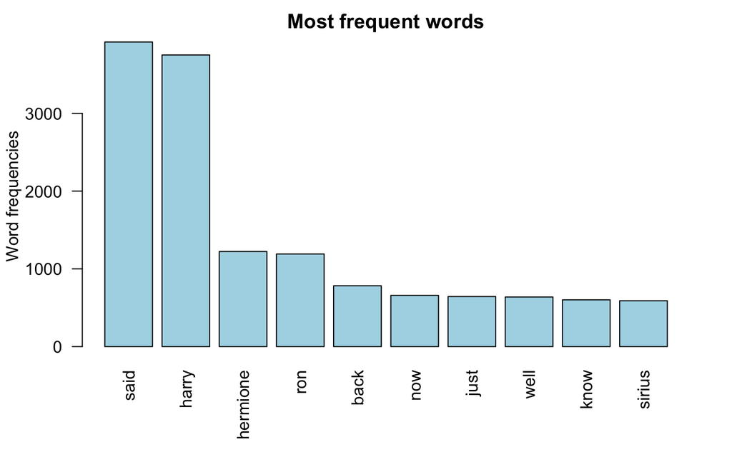

```r
barplot(dtm_d[1:10,]$freq, las = 2, names.arg = dtm_d[1:10,]$word,
        col ="lightblue", main ="Most frequent words",
        ylab = "Word frequencies")
```

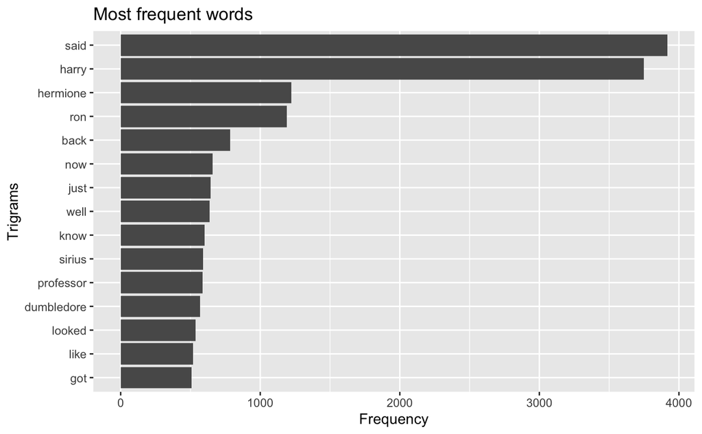

```r
ggplot(head(dtm_d,15), aes(reorder(word,freq), freq)) +
  geom_bar(stat="identity") + coord_flip() +
  xlab("Trigrams") + ylab("Frequency") +
  ggtitle("Most frequent words")
```

We can also generate a word cloud of the book:

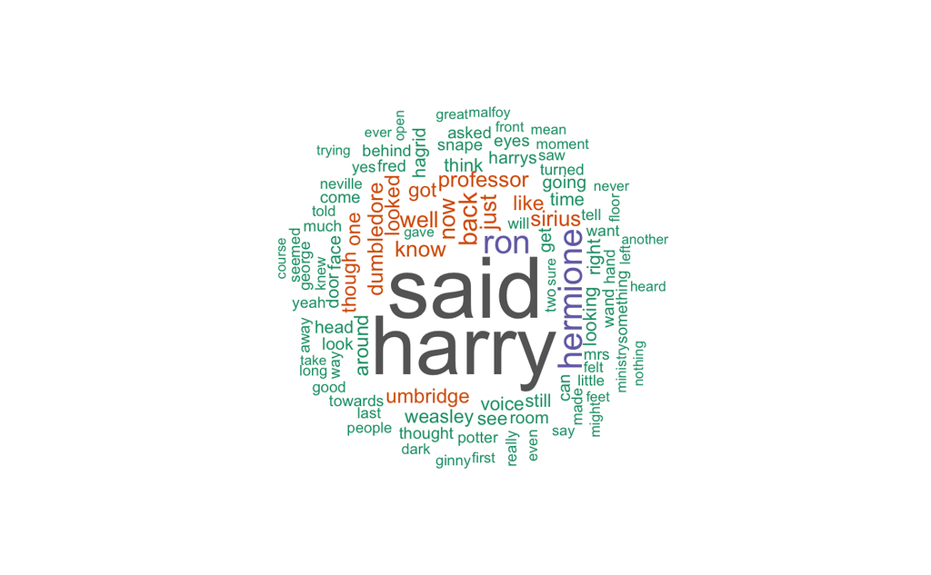

```r
set.seed(1234)
wordcloud(words = dtm_d$word, freq = dtm_d$freq, min.freq = 5,
          max.words=100, random.order=FALSE, rot.per=0.40,
          colors=brewer.pal(8, "Dark2"))
```

We can see that Ron and Hermione are Harry’s best friends. Finally, it is also clear that Sirius and Dumbledore are also close to Harry.

### Words with a frequency >= 5

```r
corpus_bag = findFreqTerms(corpus_dtm, lowfreq = 5)
class(corpus_bag)
```

```
[1] "character"
```

```r
#We can print some of the words that are in our bag of words
corpus_bag[1:50]
```

```
 [1] "harry"      "order"      "phoenix"    "potter"     "chapter"    "one"        "dudley"     "back"
 [9] "banned"     "boy"        "breeze"     "cars"       "close"      "cool"       "day"        "drawing"
[17] "drive"      "due"        "dusty"      "emerald"    "far"        "flat"       "flowerbed"  "four"
[25] "gleaming"   "green"      "hope"       "houses"     "large"      "lawns"      "lay"        "left"
[33] "lying"      "number"     "outside"    "person"     "privet"     "retreated"  "shade"      "silence"
[41] "square"     "stood"      "summer"     "thrown"     "use"        "usual"      "usually"    "wide"
[49] "windows"    "appearance"
```

## Sentiment Analysis

In this part, we are going to discover if the overall sentiment of this book is positive or negative.

First, we’ll need a list of positive and negative words.

```r
pos_file = "http://ptrckprry.com/course/ssd/data/positive-words.txt"
poswords = scan(pos_file, what='character', comment.char=';')
```

```
Read 2006 items
```

```r
poswords[1:50]
```

```
 [1] "a+"              "abound"          "abounds"         "abundance"       "abundant"        "accessable"
 [7] "accessible"      "acclaim"         "acclaimed"       "acclamation"     "accolade"        "accolades"
[13] "accommodative"   "accomodative"    "accomplish"      "accomplished"    "accomplishment"  "accomplishments"
[19] "accurate"        "accurately"      "achievable"      "achievement"     "achievements"    "achievible"
[25] "acumen"          "adaptable"       "adaptive"        "adequate"        "adjustable"      "admirable"
[31] "admirably"       "admiration"      "admire"          "admirer"         "admiring"        "admiringly"
[37] "adorable"        "adore"           "adored"          "adorer"          "adoring"         "adoringly"
[43] "adroit"          "adroitly"        "adulate"         "adulation"       "adulatory"       "advanced"
[49] "advantage"       "advantageous"
```

```r
neg_file = "http://ptrckprry.com/course/ssd/data/negative-words.txt"
negwords = scan(neg_file, what='character', comment.char=';')
```

```
Read 4783 items
```

```r
negwords[1:50]
```

```
 [1] "2-faced"       "2-faces"       "abnormal"      "abolish"       "abominable"    "abominably"    "abominate"
 [8] "abomination"   "abort"         "aborted"       "aborts"        "abrade"        "abrasive"      "abrupt"
[15] "abruptly"      "abscond"       "absence"       "absent-minded" "absentee"      "absurd"        "absurdity"
[22] "absurdly"      "absurdness"    "abuse"         "abused"        "abuses"        "abusive"       "abysmal"
[29] "abysmally"     "abyss"         "accidental"    "accost"        "accursed"      "accusation"    "accusations"
[36] "accuse"        "accuses"       "accusing"      "accusingly"    "acerbate"      "acerbic"       "acerbically"
[43] "ache"          "ached"         "aches"         "achey"         "aching"        "acrid"         "acridly"
[50] "acridness"
```

After that, based on these lists, we can find how many positive and negative words there are in our bag.

```r
match_pos = match(corpus_bag, poswords)
match_pos[1:200]
```

```
  [1]   NA   NA   NA   NA   NA   NA   NA   NA   NA   NA  234   NA   NA  360   NA   NA   NA   NA   NA   NA   NA   NA
 [23]   NA   NA   NA   NA   NA   NA   NA   NA   NA   NA   NA   NA   NA   NA   NA   NA   NA   NA   NA   NA   NA   NA
 [45]   NA   NA   NA   NA   NA   NA   NA   NA   NA   NA   NA   NA   NA   NA   NA   NA   NA   NA   NA   NA   NA   NA
 [67]   NA   NA   NA   NA   NA   NA   NA   NA   NA   NA   NA   NA   NA   NA   NA   NA   NA   NA   NA   NA   NA  309
 [89]   NA   NA   NA   NA   NA   NA   NA   NA  927   NA   NA   NA   NA   NA   NA   NA   NA   NA   NA   NA   NA   NA
[111]   NA   NA   NA   NA   NA   NA   NA   NA   NA   NA   NA   NA   NA  805   NA   NA   NA   NA   NA   NA   NA   NA
[133]   NA   NA   NA   NA   NA   NA   NA 1088   NA   NA   NA   NA   NA   NA   NA   NA   NA   NA   NA   NA   NA   NA
[155]   NA   NA   NA   NA   NA   NA   NA   NA   NA   NA   NA 1300   NA   NA   NA 1604   NA   NA   NA   NA   NA   NA
[177]   NA   NA   NA   NA   NA   NA  751   NA   NA   NA 1319   NA   NA   NA   NA   NA   NA   NA   NA   NA   NA   NA
[199]   NA   NA
```

```r
match_pos_bool = !is.na(match(corpus_bag, poswords))
match_pos_bool[1:200]
```

```
  [1] FALSE FALSE FALSE FALSE FALSE FALSE FALSE FALSE FALSE FALSE  TRUE FALSE FALSE  TRUE FALSE FALSE FALSE FALSE
 [19] FALSE FALSE FALSE FALSE FALSE FALSE FALSE FALSE FALSE FALSE FALSE FALSE FALSE FALSE FALSE FALSE FALSE FALSE
 [37] FALSE FALSE FALSE FALSE FALSE FALSE FALSE FALSE FALSE FALSE FALSE FALSE FALSE FALSE FALSE FALSE FALSE FALSE
 [55] FALSE FALSE FALSE FALSE FALSE FALSE FALSE FALSE FALSE FALSE FALSE FALSE FALSE FALSE FALSE FALSE FALSE FALSE
 [73] FALSE FALSE FALSE FALSE FALSE FALSE FALSE FALSE FALSE FALSE FALSE FALSE FALSE FALSE FALSE  TRUE FALSE FALSE
 [91] FALSE FALSE FALSE FALSE FALSE FALSE  TRUE FALSE FALSE FALSE FALSE FALSE FALSE FALSE FALSE FALSE FALSE FALSE
[109] FALSE FALSE FALSE FALSE FALSE FALSE FALSE FALSE FALSE FALSE FALSE FALSE FALSE FALSE FALSE  TRUE FALSE FALSE
[127] FALSE FALSE FALSE FALSE FALSE FALSE FALSE FALSE FALSE FALSE FALSE FALSE FALSE  TRUE FALSE FALSE FALSE FALSE
[145] FALSE FALSE FALSE FALSE FALSE FALSE FALSE FALSE FALSE FALSE FALSE FALSE FALSE FALSE FALSE FALSE FALSE FALSE
[163] FALSE FALSE FALSE  TRUE FALSE FALSE FALSE  TRUE FALSE FALSE FALSE FALSE FALSE FALSE FALSE FALSE FALSE FALSE
[181] FALSE FALSE  TRUE FALSE FALSE FALSE  TRUE FALSE FALSE FALSE FALSE FALSE FALSE FALSE FALSE FALSE FALSE FALSE
[199] FALSE FALSE
```

```r
sum(!is.na(match(corpus_bag, poswords)))
```

```
[1] 220
```

There are 220 positive words in our bag (positive words which appear at list five times in the book).

```r
sum(!is.na(match(corpus_bag, negwords)))
```

```
[1] 417
```

There are 417 negative words in our bag (negative words which appear at list five times in the book).

We can calculate the overall score of the book Harry Potter and the Order of the Phoenix:

```r
score = sum(!is.na(match(corpus_bag, poswords))) - sum(!is.na(match(corpus_bag, negwords)))
score
```

```
[1] -197
```

We can conclude that this book is a negative book which is the case because there many wars in this story.

## Conclusions

Let’s sum up all the facts that we found by analyzing the text of this book:

- Ron and Hermione are Harry’s best friends
- Sirius and Dumbledore are also close to Harry
- There are many dialogues in the book (said is the most frequent word of the book)
- There are about twice as many negative words as positive words in the book: this is a negative book, bad things happen in this story